# Pandas DataFrames

DataFrames are the workhorse of pandas and are directly inspired by the R programming language. We can **think of a DataFrame as a bunch of Series objects put together to share the same index**. Let's use pandas to explore this topic!

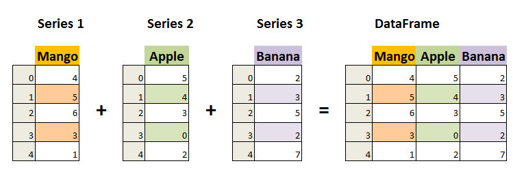

```python
import pandas as pd
import numpy as np
```

```python
from numpy.random import randn
```

```python
# pd.DataFrame?
```

```python
np.random.seed(0)  #pseudo randomness

df1 = pd.DataFrame(randn(5,4),index=['A', 'B', 'C', 'D', 'E'],columns=['W', 'X', 'Y', 'Z'])
df1
```

|  | W | X | Y | Z |
| --- | --- | --- | --- | --- |
| A | 1.764052 | 0.400157 | 0.978738 | 2.240893 |
| B | 1.867558 | -0.977278 | 0.950088 | -0.151357 |
| C | -0.103219 | 0.410599 | 0.144044 | 1.454274 |
| D | 0.761038 | 0.121675 | 0.443863 | 0.333674 |
| E | 1.494079 | -0.205158 | 0.313068 | -0.854096 |

```python
df2 = pd.DataFrame(randn(5,4))
df2
```

|  | 0 | 1 | 2 | 3 |
| --- | --- | --- | --- | --- |
| 0 | -2.552990 | 0.653619 | 0.864436 | -0.742165 |
| 1 | 2.269755 | -1.454366 | 0.045759 | -0.187184 |
| 2 | 1.532779 | 1.469359 | 0.154947 | 0.378163 |
| 3 | -0.887786 | -1.980796 | -0.347912 | 0.156349 |
| 4 | 1.230291 | 1.202380 | -0.387327 | -0.302303 |

**DataFrame Columns are just Series**

```python
type(df1['W'])
```

```
pandas.core.series.Series
```

```python
type(df1[['W','Z']])
```

```
pandas.core.frame.DataFrame
```

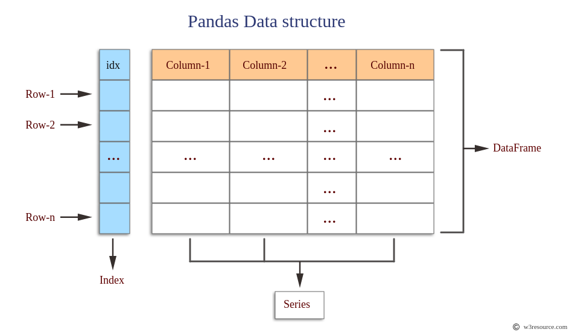

## Selection and Indexing

Let's learn the various methods to grab data from a DataFrame

### Selecting Columns

```python
df1
```

|  | W | X | Y | Z |
| --- | --- | --- | --- | --- |
| A | 1.764052 | 0.400157 | 0.978738 | 2.240893 |
| B | 1.867558 | -0.977278 | 0.950088 | -0.151357 |
| C | -0.103219 | 0.410599 | 0.144044 | 1.454274 |
| D | 0.761038 | 0.121675 | 0.443863 | 0.333674 |
| E | 1.494079 | -0.205158 | 0.313068 | -0.854096 |

```python
df1['Y']
```

```
A    0.978738
B    0.950088
C    0.144044
D    0.443863
E    0.313068
Name: Y, dtype: float64
```

```python
# Pass a list of column names
df1[['W','Z']]
```

|  | W | Z |
| --- | --- | --- |
| A | 1.764052 | 2.240893 |
| B | 1.867558 | -0.151357 |
| C | -0.103219 | 1.454274 |
| D | 0.761038 | 0.333674 |
| E | 1.494079 | -0.854096 |

```python
# SQL inspired Syntax
df1.W
```

```
A    1.764052
B    1.867558
C   -0.103219
D    0.761038
E    1.494079
Name: W, dtype: float64
```

### Selecting Rows

```python
df1
```

|  | W | X | Y | Z |
| --- | --- | --- | --- | --- |
| A | 1.764052 | 0.400157 | 0.978738 | 2.240893 |
| B | 1.867558 | -0.977278 | 0.950088 | -0.151357 |
| C | -0.103219 | 0.410599 | 0.144044 | 1.454274 |
| D | 0.761038 | 0.121675 | 0.443863 | 0.333674 |
| E | 1.494079 | -0.205158 | 0.313068 | -0.854096 |

```python
#Indexing rows by row name = use .loc

df1.loc['C']
```

```
W   -0.103219
X    0.410599
Y    0.144044
Z    1.454274
Name: C, dtype: float64
```

```python
df1.loc['A']
```

```
W    1.764052
X    0.400157
Y    0.978738
Z    2.240893
Name: A, dtype: float64
```

```python
df1.loc[['B','D']]
```

|  | W | X | Y | Z |
| --- | --- | --- | --- | --- |
| B | 1.867558 | -0.977278 | 0.950088 | -0.151357 |
| D | 0.761038 | 0.121675 | 0.443863 | 0.333674 |

```python
# df1.loc[['A','C']]
```

```python
#Row indexing by position = use .iloc

df1.iloc[2]
```

```
W   -0.103219
X    0.410599
Y    0.144044
Z    1.454274
Name: C, dtype: float64
```

```python
df1.iloc[3]
```

```
W    0.761038
X    0.121675
Y    0.443863
Z    0.333674
Name: D, dtype: float64
```

```python
df1.iloc[1]
```

```
W    1.867558
X   -0.977278
Y    0.950088
Z   -0.151357
Name: B, dtype: float64
```

### Selecting subset of rows and columns

```python
df1
```

|  | W | X | Y | Z |
| --- | --- | --- | --- | --- |
| A | 1.764052 | 0.400157 | 0.978738 | 2.240893 |
| B | 1.867558 | -0.977278 | 0.950088 | -0.151357 |
| C | -0.103219 | 0.410599 | 0.144044 | 1.454274 |
| D | 0.761038 | 0.121675 | 0.443863 | 0.333674 |
| E | 1.494079 | -0.205158 | 0.313068 | -0.854096 |

```python
df1.loc[['A','B'],['W','Y']]
```

|  | W | Y |
| --- | --- | --- |
| A | 1.764052 | 0.978738 |
| B | 1.867558 | 0.950088 |

```python
df1.iloc[:,:]
```

|  | W | X | Y | Z |
| --- | --- | --- | --- | --- |
| A | 1.764052 | 0.400157 | 0.978738 | 2.240893 |
| B | 1.867558 | -0.977278 | 0.950088 | -0.151357 |
| C | -0.103219 | 0.410599 | 0.144044 | 1.454274 |
| D | 0.761038 | 0.121675 | 0.443863 | 0.333674 |
| E | 1.494079 | -0.205158 | 0.313068 | -0.854096 |

```python
df1.iloc[:,0:2]
```

|  | W | X |
| --- | --- | --- |
| A | 1.764052 | 0.400157 |
| B | 1.867558 | -0.977278 |
| C | -0.103219 | 0.410599 |
| D | 0.761038 | 0.121675 |
| E | 1.494079 | -0.205158 |

```python
df1.iloc[0:2,0:2]
```

|  | W | X |
| --- | --- | --- |
| A | 1.764052 | 0.400157 |
| B | 1.867558 | -0.977278 |

```python
df1.iloc[0:2,:]
```

|  | W | X | Y | Z |
| --- | --- | --- | --- | --- |
| A | 1.764052 | 0.400157 | 0.978738 | 2.240893 |
| B | 1.867558 | -0.977278 | 0.950088 | -0.151357 |

[figure not shown]

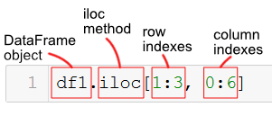

### Conditional Selection

An important feature of pandas is conditional selection using bracket notation, very similar to numpy:

```python
df1
```

|  | W | X | Y | Z |
| --- | --- | --- | --- | --- |
| A | 1.764052 | 0.400157 | 0.978738 | 2.240893 |
| B | 1.867558 | -0.977278 | 0.950088 | -0.151357 |
| C | -0.103219 | 0.410599 | 0.144044 | 1.454274 |
| D | 0.761038 | 0.121675 | 0.443863 | 0.333674 |
| E | 1.494079 | -0.205158 | 0.313068 | -0.854096 |

```python
df1 > 0
```

|  | W | X | Y | Z |
| --- | --- | --- | --- | --- |
| A | True | True | True | True |
| B | True | False | True | False |
| C | False | True | True | True |
| D | True | True | True | True |
| E | True | False | True | False |

```python
df1[df1 > 0]
```

|  | W | X | Y | Z |
| --- | --- | --- | --- | --- |
| A | 1.764052 | 0.400157 | 0.978738 | 2.240893 |
| B | 1.867558 | NaN | 0.950088 | NaN |
| C | NaN | 0.410599 | 0.144044 | 1.454274 |
| D | 0.761038 | 0.121675 | 0.443863 | 0.333674 |
| E | 1.494079 | NaN | 0.313068 | NaN |

```python
df1[df1['W'] > 0]
```

|  | W | X | Y | Z |
| --- | --- | --- | --- | --- |
| A | 1.764052 | 0.400157 | 0.978738 | 2.240893 |
| B | 1.867558 | -0.977278 | 0.950088 | -0.151357 |
| D | 0.761038 | 0.121675 | 0.443863 | 0.333674 |
| E | 1.494079 | -0.205158 | 0.313068 | -0.854096 |

```python
df1[df1['W'] > 0]['Y']
```

```
A    0.978738
B    0.950088
D    0.443863
E    0.313068
Name: Y, dtype: float64
```

```python
df1[df1['W'] > 0][['Y','X']]
```

|  | Y | X |
| --- | --- | --- |
| A | 0.978738 | 0.400157 |
| B | 0.950088 | -0.977278 |
| D | 0.443863 | 0.121675 |
| E | 0.313068 | -0.205158 |

### Creating a new column

```python
df1['new'] = df1['W'] + df1['Y']
```

```python
df1
```

|  | W | X | Y | Z | new |
| --- | --- | --- | --- | --- | --- |
| A | 1.764052 | 0.400157 | 0.978738 | 2.240893 | 2.742790 |
| B | 1.867558 | -0.977278 | 0.950088 | -0.151357 | 2.817646 |
| C | -0.103219 | 0.410599 | 0.144044 | 1.454274 | 0.040825 |
| D | 0.761038 | 0.121675 | 0.443863 | 0.333674 | 1.204901 |
| E | 1.494079 | -0.205158 | 0.313068 | -0.854096 | 1.807147 |

### Add new row

To append or add a row to DataFrame, create the new row as Series and use `DataFrame.append()` method.

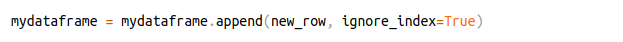

where the resulting DataFrame contains new_row added to mydataframe.

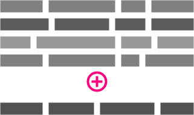

```python
df1
```

|  | W | X | Y | Z | new |
| --- | --- | --- | --- | --- | --- |
| A | 1.764052 | 0.400157 | 0.978738 | 2.240893 | 2.742790 |
| B | 1.867558 | -0.977278 | 0.950088 | -0.151357 | 2.817646 |
| C | -0.103219 | 0.410599 | 0.144044 | 1.454274 | 0.040825 |
| D | 0.761038 | 0.121675 | 0.443863 | 0.333674 | 1.204901 |
| E | 1.494079 | -0.205158 | 0.313068 | -0.854096 | 1.807147 |

### Using dictionary

The new row is initialized as a Python Dictionary and `append()` function is used to append the row to the dataframe.

**When you are adding a Python Dictionary to `append()`, make sure that you pass `ignore_index = True`**

```python
new_row = {'W':0, 'X':99, 'Y':100, 'Z':-1}

#append row to the dataframe
df1.append(new_row, ignore_index=True)
```

|  | W | X | Y | Z | new |
| --- | --- | --- | --- | --- | --- |
| 0 | 1.764052 | 0.400157 | 0.978738 | 2.240893 | 2.742790 |
| 1 | 1.867558 | -0.977278 | 0.950088 | -0.151357 | 2.817646 |
| 2 | -0.103219 | 0.410599 | 0.144044 | 1.454274 | 0.040825 |
| 3 | 0.761038 | 0.121675 | 0.443863 | 0.333674 | 1.204901 |
| 4 | 1.494079 | -0.205158 | 0.313068 | -0.854096 | 1.807147 |
| 5 | 0.000000 | 99.000000 | 100.000000 | -1.000000 | NaN |

**If you provide the parameter `ignoreIndex=False`, you will get TypeError.**

```python
#append row to the dataframe
df1 = df1.append(new_row, ignore_index=False)
```

```
---------------------------------------------------------------------------
TypeError                                 Traceback (most recent call last)
<ipython-input-36-80bee5508897> in <module>
      1 #append row to the dataframe
----> 2 df1 = df1.append(new_row, ignore_index=False)

~/.local/lib/python3.6/site-packages/pandas/core/frame.py in append(self, other, ignore_index, verify_integrity, sort)
   7709             if isinstance(other, dict):
   7710                 if not ignore_index:
-> 7711                     raise TypeError("Can only append a dict if ignore_index=True")
   7712                 other = Series(other)
   7713             if other.name is None and not ignore_index:

TypeError: Can only append a dict if ignore_index=True
```

### Using Pandas Series

```python
new_row = pd.Series(data = {'W':0, 'X':99, 'Y':100, 'Z':-1})

#append row to the dataframe
df1.append(new_row, ignore_index=True)
```

|  | W | X | Y | Z | new |
| --- | --- | --- | --- | --- | --- |
| 0 | 1.764052 | 0.400157 | 0.978738 | 2.240893 | 2.742790 |
| 1 | 1.867558 | -0.977278 | 0.950088 | -0.151357 | 2.817646 |
| 2 | -0.103219 | 0.410599 | 0.144044 | 1.454274 | 0.040825 |
| 3 | 0.761038 | 0.121675 | 0.443863 | 0.333674 | 1.204901 |
| 4 | 1.494079 | -0.205158 | 0.313068 | -0.854096 | 1.807147 |
| 5 | 0.000000 | 99.000000 | 100.000000 | -1.000000 | NaN |

**Try `ignoreIndex=False`, this time read the TypeError carefully.**

```python
new_row = pd.Series(data = {'W':0, 'X':99, 'Y':100, 'Z':-1})

#append row to the dataframe
df1.append(new_row, ignore_index=False)
```

```
---------------------------------------------------------------------------
TypeError                                 Traceback (most recent call last)
<ipython-input-38-a5e1e074de1b> in <module>
      2
      3 #append row to the dataframe
----> 4 df1.append(new_row, ignore_index=False)

~/.local/lib/python3.6/site-packages/pandas/core/frame.py in append(self, other, ignore_index, verify_integrity, sort)
   7713             if other.name is None and not ignore_index:
   7714                 raise TypeError(
-> 7715                     "Can only append a Series if ignore_index=True "
   7716                     "or if the Series has a name"
   7717                 )

TypeError: Can only append a Series if ignore_index=True or if the Series has a name
```

```python
new_row = pd.Series(data = {'W':0, 'X':99, 'Y':100, 'Z':-1}, name='P')

#append row to the dataframe
df1.append(new_row, ignore_index=False)
```

|  | W | X | Y | Z | new |
| --- | --- | --- | --- | --- | --- |
| A | 1.764052 | 0.400157 | 0.978738 | 2.240893 | 2.742790 |
| B | 1.867558 | -0.977278 | 0.950088 | -0.151357 | 2.817646 |
| C | -0.103219 | 0.410599 | 0.144044 | 1.454274 | 0.040825 |
| D | 0.761038 | 0.121675 | 0.443863 | 0.333674 | 1.204901 |
| E | 1.494079 | -0.205158 | 0.313068 | -0.854096 | 1.807147 |
| P | 0.000000 | 99.000000 | 100.000000 | -1.000000 | NaN |

**WARNING:**

`append()` does not change the DataFrame, but returns a new DataFrame with the row appended.

```python
new_row2 = pd.Series(data = {'W':0, 'X':99, 'Y':100, 'Z':-1}, name='P')

#append row to the dataframe
df1.append(new_row2, ignore_index=False)
```

|  | W | X | Y | Z | new |
| --- | --- | --- | --- | --- | --- |
| A | 1.764052 | 0.400157 | 0.978738 | 2.240893 | 2.742790 |
| B | 1.867558 | -0.977278 | 0.950088 | -0.151357 | 2.817646 |
| C | -0.103219 | 0.410599 | 0.144044 | 1.454274 | 0.040825 |
| D | 0.761038 | 0.121675 | 0.443863 | 0.333674 | 1.204901 |
| E | 1.494079 | -0.205158 | 0.313068 | -0.854096 | 1.807147 |
| P | 0.000000 | 99.000000 | 100.000000 | -1.000000 | NaN |

```python
df1
```

|  | W | X | Y | Z | new |
| --- | --- | --- | --- | --- | --- |
| A | 1.764052 | 0.400157 | 0.978738 | 2.240893 | 2.742790 |
| B | 1.867558 | -0.977278 | 0.950088 | -0.151357 | 2.817646 |
| C | -0.103219 | 0.410599 | 0.144044 | 1.454274 | 0.040825 |
| D | 0.761038 | 0.121675 | 0.443863 | 0.333674 | 1.204901 |
| E | 1.494079 | -0.205158 | 0.313068 | -0.854096 | 1.807147 |

```python
#append row to the dataframe
df1 = df1.append(new_row, ignore_index=True)
```

### Appending multiple rows

```python
#resetting data frame
np.random.seed(0)

df1 = pd.DataFrame(randn(5,4),index=['A', 'B', 'C', 'D', 'E'],columns=['W', 'X', 'Y', 'Z'])
df1
```

|  | W | X | Y | Z |
| --- | --- | --- | --- | --- |
| A | 1.764052 | 0.400157 | 0.978738 | 2.240893 |
| B | 1.867558 | -0.977278 | 0.950088 | -0.151357 |
| C | -0.103219 | 0.410599 | 0.144044 | 1.454274 |
| D | 0.761038 | 0.121675 | 0.443863 | 0.333674 |
| E | 1.494079 | -0.205158 | 0.313068 | -0.854096 |

```python
# List of series
listOfSeries = [pd.Series([0,99,100,-1], index = df1.columns),
                pd.Series([21,20,45,89], index = df1.columns),
                pd.Series([33,55,11,22], index = df1.columns)]

modified_df1 = df1.append(listOfSeries , ignore_index=True)
modified_df1
```

|  | W | X | Y | Z |
| --- | --- | --- | --- | --- |
| 0 | 1.764052 | 0.400157 | 0.978738 | 2.240893 |
| 1 | 1.867558 | -0.977278 | 0.950088 | -0.151357 |
| 2 | -0.103219 | 0.410599 | 0.144044 | 1.454274 |
| 3 | 0.761038 | 0.121675 | 0.443863 | 0.333674 |
| 4 | 1.494079 | -0.205158 | 0.313068 | -0.854096 |
| 5 | 0.000000 | 99.000000 | 100.000000 | -1.000000 |
| 6 | 21.000000 | 20.000000 | 45.000000 | 89.000000 |
| 7 | 33.000000 | 55.000000 | 11.000000 | 22.000000 |

```python
# List of series
listOfSeries = [pd.Series([0,99,100,-1], index = df1.columns),
                pd.Series([21,20,45,89], index = df1.columns),
                pd.Series([33,55,11,22], index = df1.columns)]

modified_df1 = df1.append(listOfSeries , ignore_index=False)
modified_df1
```

|  | W | X | Y | Z |
| --- | --- | --- | --- | --- |
| A | 1.764052 | 0.400157 | 0.978738 | 2.240893 |
| B | 1.867558 | -0.977278 | 0.950088 | -0.151357 |
| C | -0.103219 | 0.410599 | 0.144044 | 1.454274 |
| D | 0.761038 | 0.121675 | 0.443863 | 0.333674 |
| E | 1.494079 | -0.205158 | 0.313068 | -0.854096 |
| 0 | 0.000000 | 99.000000 | 100.000000 | -1.000000 |
| 1 | 21.000000 | 20.000000 | 45.000000 | 89.000000 |
| 2 | 33.000000 | 55.000000 | 11.000000 | 22.000000 |

### Removing Columns

```python
#creating a data frame
np.random.seed(0)

df = pd.DataFrame(randn(10,3),columns=['ABC', 'PQR', 'XYZ'])
df
```

|  | ABC | PQR | XYZ |
| --- | --- | --- | --- |
| 0 | 1.764052 | 0.400157 | 0.978738 |
| 1 | 2.240893 | 1.867558 | -0.977278 |
| 2 | 0.950088 | -0.151357 | -0.103219 |
| 3 | 0.410599 | 0.144044 | 1.454274 |
| 4 | 0.761038 | 0.121675 | 0.443863 |
| 5 | 0.333674 | 1.494079 | -0.205158 |
| 6 | 0.313068 | -0.854096 | -2.552990 |
| 7 | 0.653619 | 0.864436 | -0.742165 |
| 8 | 2.269755 | -1.454366 | 0.045759 |
| 9 | -0.187184 | 1.532779 | 1.469359 |

```python
df.drop(columns = 'PQR')  # single columns

# df.drop(columns = ['PQR','XYZ'])  # multiple columns
```

|  | ABC | XYZ |
| --- | --- | --- |
| 0 | 1.764052 | 0.978738 |
| 1 | 2.240893 | -0.977278 |
| 2 | 0.950088 | -0.103219 |
| 3 | 0.410599 | 1.454274 |
| 4 | 0.761038 | 0.443863 |
| 5 | 0.333674 | -0.205158 |
| 6 | 0.313068 | -2.552990 |
| 7 | 0.653619 | -0.742165 |
| 8 | 2.269755 | 0.045759 |
| 9 | -0.187184 | 1.469359 |

```python
# alternatively

df.drop('PQR', axis=1)  #axis = 1: columns
```

|  | ABC | XYZ |
| --- | --- | --- |
| 0 | 1.764052 | 0.978738 |
| 1 | 2.240893 | -0.977278 |
| 2 | 0.950088 | -0.103219 |
| 3 | 0.410599 | 1.454274 |
| 4 | 0.761038 | 0.443863 |
| 5 | 0.333674 | -0.205158 |
| 6 | 0.313068 | -2.552990 |
| 7 | 0.653619 | -0.742165 |
| 8 | 2.269755 | 0.045759 |
| 9 | -0.187184 | 1.469359 |

### Removing Rows

```python
df.drop(index = 0)
```

|  | ABC | PQR | XYZ |
| --- | --- | --- | --- |
| 1 | 2.240893 | 1.867558 | -0.977278 |
| 2 | 0.950088 | -0.151357 | -0.103219 |
| 3 | 0.410599 | 0.144044 | 1.454274 |
| 4 | 0.761038 | 0.121675 | 0.443863 |
| 5 | 0.333674 | 1.494079 | -0.205158 |
| 6 | 0.313068 | -0.854096 | -2.552990 |
| 7 | 0.653619 | 0.864436 | -0.742165 |
| 8 | 2.269755 | -1.454366 | 0.045759 |
| 9 | -0.187184 | 1.532779 | 1.469359 |

```python
df.drop(index = [0,1])
```

|  | ABC | PQR | XYZ |
| --- | --- | --- | --- |
| 2 | 0.950088 | -0.151357 | -0.103219 |
| 3 | 0.410599 | 0.144044 | 1.454274 |
| 4 | 0.761038 | 0.121675 | 0.443863 |
| 5 | 0.333674 | 1.494079 | -0.205158 |
| 6 | 0.313068 | -0.854096 | -2.552990 |
| 7 | 0.653619 | 0.864436 | -0.742165 |
| 8 | 2.269755 | -1.454366 | 0.045759 |
| 9 | -0.187184 | 1.532779 | 1.469359 |

```python
# alternatively

df.drop(0, axis = 0)  #axis = 0: rows
```

|  | ABC | PQR | XYZ |
| --- | --- | --- | --- |
| 1 | 2.240893 | 1.867558 | -0.977278 |
| 2 | 0.950088 | -0.151357 | -0.103219 |
| 3 | 0.410599 | 0.144044 | 1.454274 |
| 4 | 0.761038 | 0.121675 | 0.443863 |
| 5 | 0.333674 | 1.494079 | -0.205158 |
| 6 | 0.313068 | -0.854096 | -2.552990 |
| 7 | 0.653619 | 0.864436 | -0.742165 |
| 8 | 2.269755 | -1.454366 | 0.045759 |
| 9 | -0.187184 | 1.532779 | 1.469359 |

```python
df.drop(index = 0,columns = 'ABC')
```

|  | PQR | XYZ |
| --- | --- | --- |
| 1 | 1.867558 | -0.977278 |
| 2 | -0.151357 | -0.103219 |
| 3 | 0.144044 | 1.454274 |
| 4 | 0.121675 | 0.443863 |
| 5 | 1.494079 | -0.205158 |
| 6 | -0.854096 | -2.552990 |
| 7 | 0.864436 | -0.742165 |
| 8 | -1.454366 | 0.045759 |
| 9 | 1.532779 | 1.469359 |

#### Note that the original 'data' object is still not changed

```python
df
```

|  | ABC | PQR | XYZ |
| --- | --- | --- | --- |
| 0 | 1.764052 | 0.400157 | 0.978738 |
| 1 | 2.240893 | 1.867558 | -0.977278 |
| 2 | 0.950088 | -0.151357 | -0.103219 |
| 3 | 0.410599 | 0.144044 | 1.454274 |
| 4 | 0.761038 | 0.121675 | 0.443863 |
| 5 | 0.333674 | 1.494079 | -0.205158 |
| 6 | 0.313068 | -0.854096 | -2.552990 |
| 7 | 0.653619 | 0.864436 | -0.742165 |
| 8 | 2.269755 | -1.454366 | 0.045759 |
| 9 | -0.187184 | 1.532779 | 1.469359 |

#### setting `inplace = True` can make changes in the original dataframe

```python
df.drop(index = 0,columns = 'ABC', inplace = True)

df #checking original dataframe
```

|  | PQR | XYZ |
| --- | --- | --- |
| 1 | 1.867558 | -0.977278 |
| 2 | -0.151357 | -0.103219 |
| 3 | 0.144044 | 1.454274 |
| 4 | 0.121675 | 0.443863 |
| 5 | 1.494079 | -0.205158 |
| 6 | -0.854096 | -2.552990 |
| 7 | 0.864436 | -0.742165 |
| 8 | -1.454366 | 0.045759 |
| 9 | 1.532779 | 1.469359 |